# Folder Structure

Leonard-Allen

2022-07-14

# Folder Structure

This is the structure we will use for our ShinyApp from now. The structure is similar to the set up in our [GitHub repo](https://github.com/leoallen8/2022_DSPG_Zimbabwe) wit the ShinyApp folder. Please follow this closely and make this folder in your branch for now.

## Main Folder: “ShinyApp”. This is also the working directory.

see link: https://github.com/leoallen8/2022_DSPG_Zimbabwe/tree/main/ShinyApp

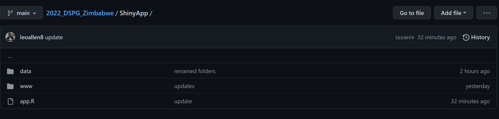

Under the main we have the following subfolders Sub-folders/files:

- data : strictly the data files that will make the shiny app run
- www: image and other media files
- app.R (script)

NB: This folder will also contain the app.R script for the shiny (and then the rsconnect after deployment to shinyapps.io)

## within the ShinyApp/data folder

see link: https://github.com/leoallen8/2022_DSPG_Zimbabwe/tree/main/ShinyApp/data

[figure not shown]

### within the ShinyApp/data/agregion folder

Because we are working on the agro-ecological regions; See link: https://github.com/leoallen8/2022_DSPG_Zimbabwe/tree/main/ShinyApp/data/agregion

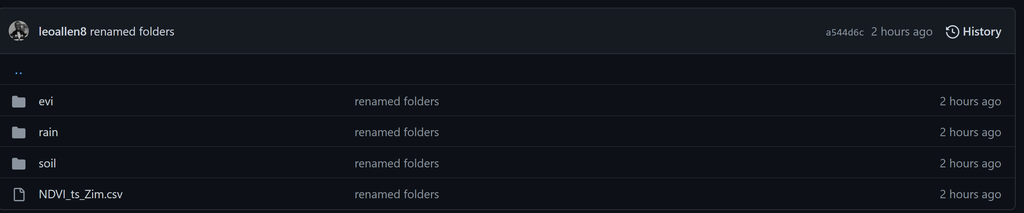

### - ShinyApp/data/agregion/evi

[figure not shown]

### - ShinyApp/data/agregion/rain

[figure not shown]

### - ShinyApp/data/agregion/soil

[figure not shown]

# Reading data samples

[tip set the working directory to the ShinyApp folder]

*Reading shapefile*

zim_district <- st_read(“./data/shapefiles/Zim_D60.shp”)

zim_region <- st_read(“./data/shapefiles/agro-ecological-regions.shp”)

*Frankie EVI:*

GrSs2017 <- read_csv(“./data/agregion/evi/EVI_region_GrSs2017.csv”)

EVI_region_long <- read_csv(“./data/agregion/evi/EVI_region_long.csv”)

*Ari Soil:*

mydatXL2 <- read_csv(paste0(getwd(),“/data/agregion/soil/soil_ts_Zimb.csv”))

mydat_long <- readRDS(“./data/agregion/soil/mydat_long.RDS”)

End